# Employee Attrition Example

# Introduction

Awhile ago, during my time at Centura Health, I began researching all the different ways we could analyze the data at hand. And at some point I became very interested in HR analytics. It was a fascinating way to explore an organization through data. Of course, while digesting the org structure through network graphs is interesting there are also more immediately clear benefits from employee data; predicting turnover.

I came across this [article](https://www.business-science.io/business/2017/09/18/hr_employee_attrition.html) on using machine learning, specifically [h2o](https://www.h2o.ai/) and [Lime](https://arxiv.org/abs/1602.04938), for turnover prediction and really liked the simplicity of the features included, as well as, the author’s explanation. After setting this example aside for some time, I finally found the time to work through this example and peeking under the h2o hood attempt to replicate the results using [GLMNET](https://glmnet.stanford.edu/articles/glmnet.html).

# The Data

Unfortunately, the link to the data in the original article is broken. After a little bit of Googling I was able to find some conscientious Github repos with a copy. I did some checks and the data seemed to match the same as the article. Since I no longer remember where I found the data, it’s hosted in my own repo now.

**[Data](https://github.com/hoffmben/ML/tree/master/h2o/employee_attrition/data)**

# EDA

Here we’ll look at the employee data and convert characters to factors.

```r
employee_attrition_raw %>%
  head(10) %>%
  knitr::kable(format = 'html') %>%
  kableExtra::kable_styling() %>%
  kableExtra::scroll_box(width = "100%", height = "750px")
```

| Age | Attrition | BusinessTravel | DailyRate | Department | DistanceFromHome | Education | EducationField | EmployeeCount | EmployeeNumber | EnvironmentSatisfaction | Gender | HourlyRate | JobInvolvement | JobLevel | JobRole | JobSatisfaction | MaritalStatus | MonthlyIncome | MonthlyRate | NumCompaniesWorked | Over18 | OverTime | PercentSalaryHike | PerformanceRating | RelationshipSatisfaction | StandardHours | StockOptionLevel | TotalWorkingYears | TrainingTimesLastYear | … |
| --- | --- | --- | --- | --- | --- | --- | --- | --- | --- | --- | --- | --- | --- | --- | --- | --- | --- | --- | --- | --- | --- | --- | --- | --- | --- | --- | --- | --- | --- | --- |
| 41 | Yes | Travel_Rarely | 1102 | Sales | 1 | 2 | Life Sciences | 1 | 1 | 2 | Female | 94 | 3 | 2 | Sales Executive | 4 | Single | 5993 | 19479 | 8 | Y | Yes | 11 | 3 | 1 | 80 | 0 | 8 | 0 | … |
| 49 | No | Travel_Frequently | 279 | Research & Development | 8 | 1 | Life Sciences | 1 | 2 | 3 | Male | 61 | 2 | 2 | Research Scientist | 2 | Married | 5130 | 24907 | 1 | Y | No | 23 | 4 | 4 | 80 | 1 | 10 | 3 | … |
| 37 | Yes | Travel_Rarely | 1373 | Research & Development | 2 | 2 | Other | 1 | 4 | 4 | Male | 92 | 2 | 1 | Laboratory Technician | 3 | Single | 2090 | 2396 | 6 | Y | Yes | 15 | 3 | 2 | 80 | 0 | 7 | 3 | … |
| 33 | No | Travel_Frequently | 1392 | Research & Development | 3 | 4 | Life Sciences | 1 | 5 | 4 | Female | 56 | 3 | 1 | Research Scientist | 3 | Married | 2909 | 23159 | 1 | Y | Yes | 11 | 3 | 3 | 80 | 0 | 8 | 3 | … |
| 27 | No | Travel_Rarely | 591 | Research & Development | 2 | 1 | Medical | 1 | 7 | 1 | Male | 40 | 3 | 1 | Laboratory Technician | 2 | Married | 3468 | 16632 | 9 | Y | No | 12 | 3 | 4 | 80 | 1 | 6 | 3 | … |
| 32 | No | Travel_Frequently | 1005 | Research & Development | 2 | 2 | Life Sciences | 1 | 8 | 4 | Male | 79 | 3 | 1 | Laboratory Technician | 4 | Single | 3068 | 11864 | 0 | Y | No | 13 | 3 | 3 | 80 | 0 | 8 | 2 | … |
| 59 | No | Travel_Rarely | 1324 | Research & Development | 3 | 3 | Medical | 1 | 10 | 3 | Female | 81 | 4 | 1 | Laboratory Technician | 1 | Married | 2670 | 9964 | 4 | Y | Yes | 20 | 4 | 1 | 80 | 3 | 12 | 3 | … |
| 30 | No | Travel_Rarely | 1358 | Research & Development | 24 | 1 | Life Sciences | 1 | 11 | 4 | Male | 67 | 3 | 1 | Laboratory Technician | 3 | Divorced | 2693 | 13335 | 1 | Y | No | 22 | 4 | 2 | 80 | 1 | 1 | 2 | … |
| 38 | No | Travel_Frequently | 216 | Research & Development | 23 | 3 | Life Sciences | 1 | 12 | 4 | Male | 44 | 2 | 3 | Manufacturing Director | 3 | Single | 9526 | 8787 | 0 | Y | No | 21 | 4 | 2 | 80 | 0 | 10 | 2 | … |
| 36 | No | Travel_Rarely | 1299 | Research & Development | 27 | 3 | Medical | 1 | 13 | 3 | Male | 94 | 3 | 2 | Healthcare Representative | 3 | Married | 5237 | 16577 | 6 | Y | No | 13 | 3 | 2 | 80 | 2 | 17 | 3 | … |

```r
# Change to factors

employee_attrition <- employee_attrition_raw %>%
  dplyr::mutate_if(is.character, as.factor) %>%
  dplyr::select(Attrition, dplyr::everything())
```

In total we have 1470 observations and 35 features.

```r
tibble::glimpse(employee_attrition, width = 100)
```

```
## Observations: 1,470
## Variables: 35
## $ Attrition                <fct> Yes, No, Yes, No, No, No, No, No, No, No, No, No, No, No, Yes, N…
## $ Age                      <dbl> 41, 49, 37, 33, 27, 32, 59, 30, 38, 36, 35, 29, 31, 34, 28, 29, …
## $ BusinessTravel           <fct> Travel_Rarely, Travel_Frequently, Travel_Rarely, Travel_Frequent…
## $ DailyRate                <dbl> 1102, 279, 1373, 1392, 591, 1005, 1324, 1358, 216, 1299, 809, 15…
## $ Department               <fct> Sales, Research & Development, Research & Development, Research …
## $ DistanceFromHome         <dbl> 1, 8, 2, 3, 2, 2, 3, 24, 23, 27, 16, 15, 26, 19, 24, 21, 5, 16, …
## $ Education                <dbl> 2, 1, 2, 4, 1, 2, 3, 1, 3, 3, 3, 2, 1, 2, 3, 4, 2, 2, 4, 3, 2, 4…
## $ EducationField           <fct> Life Sciences, Life Sciences, Other, Life Sciences, Medical, Lif…
## $ EmployeeCount            <dbl> 1, 1, 1, 1, 1, 1, 1, 1, 1, 1, 1, 1, 1, 1, 1, 1, 1, 1, 1, 1, 1, 1…
## $ EmployeeNumber           <dbl> 1, 2, 4, 5, 7, 8, 10, 11, 12, 13, 14, 15, 16, 18, 19, 20, 21, 22…
## $ EnvironmentSatisfaction  <dbl> 2, 3, 4, 4, 1, 4, 3, 4, 4, 3, 1, 4, 1, 2, 3, 2, 1, 4, 1, 4, 1, 3…
## $ Gender                   <fct> Female, Male, Male, Female, Male, Male, Female, Male, Male, Male…
## $ HourlyRate               <dbl> 94, 61, 92, 56, 40, 79, 81, 67, 44, 94, 84, 49, 31, 93, 50, 51, …
```

[output cut: 22 more lines]

## Imbalance and Feature to Observation Ratio

Let’s take a quick look at the number of positive and negative cases to ensure we don’t need to investigate sampling methods such as down/up sampling or synthetic sampling.

```r
case_table <- employee_attrition %>%
  dplyr::count(Attrition, name = "Count") %>%
  dplyr::mutate(prop = Count / sum(Count))

case_table
```

```
## # A tibble: 2 x 3
##   Attrition Count  prop
##   <fct>     <int> <dbl>
## 1 No         1233 0.839
## 2 Yes         237 0.161
```

We do see we have some moderate observation imbalance. To keep consistent with the analysis performed in the article we’ll leave as is and note this for future analysis.

Although, we’re letting H20 decide the optimal model for us let’s still check we have enough observations per variable under a logistic regression model.

Per [Peduzzi et al.](https://www.ncbi.nlm.nih.gov/pubmed/8970487) N = 10 * k / p, where N is the number of observations, k is the number of features, and p is the number of cases.

```r
k <- length(colnames(employee_attrition[, -1]))
p <- case_table %>%
  {`[[`(., 3)[2]}

N <- 10 * k / p

N
```

```
## [1] 2108.861
```

# Model Setup

Here we’ll setup our model and establish training, test, and validation sets.

```r
h2o::h2o.init()
```

```
##
## H2O is not running yet, starting it now...
##
## Note:  In case of errors look at the following log files:
##     /tmp/RtmpUmXXBs/h2o_ben_started_from_r.out
##     /tmp/RtmpUmXXBs/h2o_ben_started_from_r.err
##
##
## Starting H2O JVM and connecting: . Connection successful!
##
## R is connected to the H2O cluster:
##     H2O cluster uptime:         1 seconds 213 milliseconds
##     H2O cluster timezone:       Etc/UTC
##     H2O data parsing timezone:  UTC
##     H2O cluster version:        3.28.0.1
##     H2O cluster version age:    1 month and 20 days
##     H2O cluster name:           H2O_started_from_R_ben_ugd504
##     H2O cluster total nodes:    1
##     H2O cluster total memory:   6.96 GB
##     H2O cluster total cores:    4
##     H2O cluster allowed cores:  4
##     H2O cluster healthy:        TRUE
##     H2O Connection ip:          localhost
##     H2O Connection port:        54321
##     H2O Connection proxy:       NA
##     H2O Internal Security:      FALSE
##     H2O API Extensions:         Amazon S3, XGBoost, Algos, AutoML, Core V3, TargetEncoder, Core V4
##     R Version:                  R version 3.6.2 (2019-12-12)
```

```r
h2o::h2o.no_progress()
```

```r
employee_attrition_h2o <- h2o::as.h2o(employee_attrition)

split_h2o <- h2o::h2o.splitFrame(employee_attrition_h2o, c(0.7, 0.15), seed = 1234)

train_h2o <- h2o::h2o.assign(split_h2o[[1]], "train")
valid_h2o <- h2o::h2o.assign(split_h2o[[2]], "valid")
test_h2o <- h2o::h2o.assign(split_h2o[[3]], "test")
```

```r
y <- "Attrition"
x <- setdiff(names(train_h2o), y)
```

Time for the modeling step!

```r
automl_models_h2o <- h2o::h2o.automl(
  x = x,
  y = y,
  training_frame = train_h2o,
  leaderboard_frame = valid_h2o,
  max_runtime_secs = 30,
  seed = 1234
)

automl_leader <- automl_models_h2o@leader
```

# Evaluation

Let’s evaluate the model’s performance.

One interesting thing to note is at this step we’re not even aware of the model H2O has selected. That’s an interesting feature of the AutoML; we’re focused on the results instead of selecting features and optimizing parameters at this stage.

```r
pred_h2o <- h2o::h2o.predict(object = automl_leader, newdata = test_h2o)
```

```r
test_performance <- test_h2o %>%
  tibble::as_tibble() %>%
  dplyr::select(Attrition) %>%
  dplyr::mutate(pred = as.vector(pred_h2o$predict)) %>%
  dplyr::mutate_if(is.character, as.factor)

test_performance
```

```
## # A tibble: 211 x 2
##    Attrition pred
##    <fct>     <fct>
##  1 No        No
##  2 No        No
##  3 Yes       Yes
##  4 No        No
##  5 No        No
##  6 No        No
##  7 Yes       Yes
##  8 No        No
##  9 No        No
## 10 Yes       Yes
## # … with 201 more rows
```

```r
confusion_matrix <- test_performance %>%
  table()

confusion_matrix
```

```
##          pred
## Attrition  No Yes
##       No  170  12
##       Yes  13  16
```

```r
tn <- confusion_matrix[1]
tp <- confusion_matrix[4]
fp <- confusion_matrix[3]
fn <- confusion_matrix[2]

accuracy <- (tp + tn) / (tp + tn + fp + fn)
misclassification_rate <- 1 - accuracy
recall <- tp / (tp + fn)
precision <- tp / (tp + fp)
null_error_rate <- tn / (tp + tn + fp + fn)

tibble::tibble(
  accuracy,
  misclassification_rate,
  recall,
  precision,
  null_error_rate
) %>%
  t()
```

```
##                             [,1]
## accuracy               0.8815166
## misclassification_rate 0.1184834
## recall                 0.5517241
## precision              0.5714286
## null_error_rate        0.8056872
```

# A Peek Under The Hood

```r
automl_leader
```

```
## Model Details:
## ==============
##
## H2OBinomialModel: stackedensemble
## Model ID:  StackedEnsemble_BestOfFamily_AutoML_20200206_044731
## NULL
##
##
## H2OBinomialMetrics: stackedensemble
## ** Reported on training data. **
##
## MSE:  0.02772933
## RMSE:  0.1665212
## LogLoss:  0.1215058
## Mean Per-Class Error:  0.04749831
## AUC:  0.9964706
## AUCPR:  0.958869
## Gini:  0.9929412
##
## Confusion Matrix (vertical: actual; across: predicted) for F1-optimal threshold:
##         No Yes    Error      Rate
## No     859  11 0.012644   =11/870
## Yes     14 156 0.082353   =14/170
## Totals 873 167 0.024038  =25/1040
##
## Maximum Metrics: Maximum metrics at their respective thresholds
##                         metric threshold      value idx
## 1                       max f1  0.302228   0.925816 137
## 2                       max f2  0.199425   0.957207 172
## 3                 max f0point5  0.417172   0.944730 123
## 4                 max accuracy  0.302228   0.975962 137
## 5                max precision  0.992197   1.000000   0
## 6                   max recall  0.199425   1.000000 172
## 7              max specificity  0.992197   1.000000   0
## 8             max absolute_mcc  0.302228   0.911526 137
## 9   max min_per_class_accuracy  0.234473   0.970588 156
## 10 max mean_per_class_accuracy  0.199425   0.978161 172
## 11                     max tns  0.992197 870.000000   0
## 12                     max fns  0.992197 166.000000   0
## 13                     max fps  0.026594 870.000000 399
```

[output cut: 33 more lines]

```
## 6                   max recall  0.029366   1.000000 393
## 7              max specificity  0.989688   1.000000   0
## 8             max absolute_mcc  0.394694   0.550091 119
## 9   max min_per_class_accuracy  0.115575   0.756322 250
## 10 max mean_per_class_accuracy  0.209415   0.776099 182
## 11                     max tns  0.989688 870.000000   0
## 12                     max fns  0.989688 169.000000   0
## 13                     max fps  0.025840 870.000000 399
## 14                     max tps  0.029366 170.000000 393
## 15                     max tnr  0.989688   1.000000   0
## 16                     max fnr  0.989688   0.994118   0
## 17                     max fpr  0.025840   1.000000 399
## 18                     max tpr  0.029366   1.000000 393
##
## Gains/Lift Table: Extract with `h2o.gainsLift(<model>, <data>)` or `h2o.gainsLift(<model>, valid=<T/F>, xval=<T/F>)`
```

Of note, for the next section and unsurprisingly, we’ll use the family, link, and regularization info.

# GLMNET Comparison

Here we’ll split our sample according to the same test and training sets we used in our H2O model.

I’ll drop the feature Over18 since it’s a constant factor and doesn’t add any additional information to the outcome.

```r
x_train <- rbind(as.data.frame(train_h2o[x][, -c(21)]), as.data.frame(valid_h2o[x][, -c(21)]))
y_train <- rbind(as.data.frame(train_h2o[y]), as.data.frame(valid_h2o[y]))$Attrition

x_test <- as.data.frame(test_h2o[x][, -c(21)])
y_test <- as.data.frame(test_h2o[y])$Attrition
```

```r
x_train <- model.matrix(~.-1, x_train)

x_test <- model.matrix(~.-1, x_test)
```

Since it’s not apparent the value of alpha, although, we do have a hint (Ridge Regression), we’ll perform a grid search over alpha.

```r
alpha_grid <- seq(0, 1, .1)

model_fits <- lapply(alpha_grid, function(alpha){

  set.seed(1234)

  glmnet::cv.glmnet(x_train, as.factor(y_train),
                    family = "binomial",
                    alpha = alpha,
                    type.measure = "mse",
                    nfolds = 20
                    )

})

mse_lambda_min <- lapply(model_fits, function(model){

  lambda_min_mse <- model$cvm[which(model$lambda == model$lambda.min) ]

  lambda_1se_mse <- model$cvm[which(model$lambda == model$lambda.1se) ]

  lambda_min <- model$lambda.min

  lambda_1se <- model$lambda.1se

  data.frame(lambda_min_mse = lambda_min_mse, lambda_min = lambda_min, lambda_1se_mse = lambda_1se_mse, lambda_1se = lambda_1se)
  })

mse_lambda_min <- do.call(rbind, mse_lambda_min)

mse_lambda_min$alpha <- alpha_grid

mse_lambda_min
```

```
##    lambda_min_mse  lambda_min lambda_1se_mse  lambda_1se alpha
## 1       0.1910575 0.008881137      0.1994429 0.052017005   0.0
## 2       0.1910322 0.007724360      0.1992090 0.037560485   0.1
## 3       0.1910282 0.006749269      0.2000218 0.029903457   0.2
## 4       0.1910617 0.005948091      0.2002854 0.024012547   0.3
## 5       0.1910651 0.005897270      0.2002692 0.019765305   0.4
## 6       0.1910490 0.005177797      0.1991611 0.015812244   0.5
## 7       0.1910771 0.004314831      0.2000434 0.014461599   0.6
## 8       0.1911163 0.004059019      0.1994610 0.012395656   0.7
## 9       0.1911311 0.003551641      0.1990230 0.010846199   0.8
## 10      0.1911558 0.003157014      0.2004191 0.010581058   0.9
## 11      0.1911867 0.002841313      0.2001205 0.009522952   1.0
```

Interestingly, enough we do not see our value of lambda. There’s a couple of reasons for this:

- GLMNET picks a validation set at random whereas for the H2O model we specified this beforehand.
- The [solver](http://docs.h2o.ai/h2o/latest-stable/h2o-docs/booklets/GLMBooklet.pdf) for our lambda search seems to be different from GLMNET.

```r
glmnet_min <- glmnet::glmnet(x_train, as.factor(y_train),
                             family = "binomial",
                             alpha = 0.2,
                             lambda = 0.005412513
                             )

glmnet_1se <- glmnet::glmnet(x_train, as.factor(y_train),
                             family = "binomial",
                             alpha = 0.4,
                             lambda = 0.02299651
                             )
```

```r
glmnet_min_pred <- predict(glmnet_min,
                           s = "lambda.min",
                           newx = x_test,
                           type = "class"
                           )

glmnet_1se_pred <- predict(glmnet_1se,
                           s = "lambda.1se",
                           newx = x_test,
                           type = "class"
                           )
```

To make measure performance for our 2 models, we’ll make it easy and create a performance function.

```r
perfomance <- function(confusion_matrix) {
  tn <- confusion_matrix[1]
  tp <- confusion_matrix[4]
  fp <- confusion_matrix[3]
  fn <- confusion_matrix[2]

  accuracy <- (tp + tn) / (tp + tn + fp + fn)
  misclassification_rate <- 1 - accuracy
  recall <- tp / (tp + fn)
  precision <- tp / (tp + fp)
  null_error_rate <- tn / (tp + tn + fp + fn)

  tibble::tibble(
    accuracy,
    misclassification_rate,
    recall,
    precision,
    null_error_rate
  ) %>%
    t()
}
```

A quick look at our confusion matrix highlights a mixed recall.

```r
glmnet_min_confusion <- table(y_test, glmnet_min_pred, dnn = c("Attrition", "Prediction"))
glmnet_min_confusion
```

```
##          Prediction
## Attrition  No Yes
##       No  173   9
##       Yes  14  15
```

Compared to our H2O model, the accuracy is slightly higher. However, our recall is lower. The gap between our null error and accuracy has closed slightly.

```r
perfomance(glmnet_min_confusion)
```

```
##                             [,1]
## accuracy               0.8909953
## misclassification_rate 0.1090047
## recall                 0.5172414
## precision              0.6250000
## null_error_rate        0.8199052
```

Our 1se model has likewise traded in recall for precision. As you can see from the confusion matrix the model is very certain when it predicts yes it’s correct. However, we’ve closed the gap even more between our null error rate and accuracy.

```r
glmnet_1se_confusion <- table(y_test, glmnet_1se_pred, dnn = c("Attrition", "Prediction"))
glmnet_1se_confusion
```

```
##          Prediction
## Attrition  No Yes
##       No  181   1
##       Yes  21   8
```

```r
perfomance(glmnet_1se_confusion)
```

```
##                             [,1]
## accuracy               0.8957346
## misclassification_rate 0.1042654
## recall                 0.2758621
## precision              0.8888889
## null_error_rate        0.8578199
```

## GLMNET Conclusions

Overall, the GLMNET model has similar results to the H2O model, but it does tend to focus more on accuracy and precision at the expense of recall. It’s important to keep these things in mind when developing a model and ensuring you’re optimizing for the task at hand.

We’ll return now to the original article.

# Feature Importance

Here we’ll use the lime package to feature importance plots.

Just to note an appealing aspect of lime is it being model agnostic. We can apply the same technique regardless of it being random forest or neural network.

Since lime is still only a few years old I’ll give a brief explanation of what lime does. The first step is taking one of our predicted observations and creating slight perturbations of the original observation and finding the predictions using the original model. Finally, it fits a linear model based on the local characteristics of the model.

## Lime Setup

```r
require('lime')
model_type.H2OBinomialModel <- function(x, ...) return('classification')

predict_model.H2OBinomialModel <- function(x, newdata, type, ...) {
  pred <- h2o::h2o.predict(x, h2o::as.h2o(newdata))

  return(as.data.frame(pred[, -1]))

}
```

```r
predict_model(x = automl_leader, newdata = as.data.frame(test_h2o[, -1]), type = 'raw') %>%
  tibble::as_tibble()
```

```
## # A tibble: 211 x 2
##        No    Yes
##     <dbl>  <dbl>
##  1 0.858  0.142
##  2 0.957  0.0426
##  3 0.0563 0.944
##  4 0.966  0.0341
##  5 0.890  0.110
##  6 0.956  0.0442
##  7 0.138  0.862
##  8 0.939  0.0612
##  9 0.909  0.0912
## 10 0.456  0.544
## # … with 201 more rows
```

```r
explainer <- lime::lime(
  as.data.frame(train_h2o[, -1]),
  model = automl_leader,
  bin_continuous = FALSE
)
```

```r
explanation <- lime::explain(
  as.data.frame(test_h2o[1:10, -1]),
  explainer = explainer,
  n_labels = 1,
  n_features = 4,
  kernel_width = 0.5
)
```

Let’s take a look at the feature importance plots from lime.

Note these differ quite a bit from those found in the article. This highlights, an important point about reproducibilty. Since the authors didn’t disclose or set a seed value for the AutoML we cannot reproduce their results; it’s been left up to chance. As you can see below the feature importance gives a very different perspective on the possible interventions of attrition.

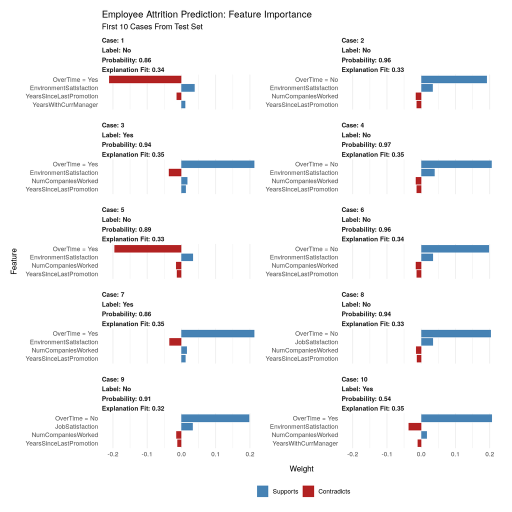

```r
lime::plot_features(explanation) +
  ggplot2::labs(title = "Employee Attrition Prediction: Feature Importance",
       subtitle = "First 10 Cases From Test Set")
```

## Author’s Feature Importance

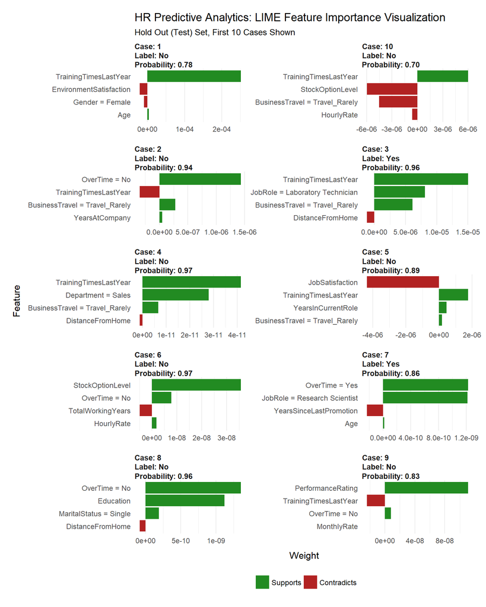

# Feature Evaluation

From the feature plots we generated, a few things stand out as important features in which we can explore and possible create intervention plans.

```r
attrition_critical_features <- employee_attrition %>%
  tibble::as_tibble() %>%
  dplyr::select(Attrition, NumCompaniesWorked, YearsSinceLastPromotion, OverTime) %>%
  dplyr::mutate(Case = dplyr::row_number()) %>%
  dplyr::select(Case, dplyr::everything())

attrition_critical_features
```

```
## # A tibble: 1,470 x 5
##     Case Attrition NumCompaniesWorked YearsSinceLastPromotion OverTime
##    <int> <fct>                  <dbl>                   <dbl> <fct>
##  1     1 Yes                        8                       0 Yes
##  2     2 No                         1                       1 No
##  3     3 Yes                        6                       0 Yes
##  4     4 No                         1                       3 Yes
##  5     5 No                         9                       2 No
##  6     6 No                         0                       3 No
##  7     7 No                         4                       0 Yes
##  8     8 No                         1                       0 No
##  9     9 No                         0                       1 No
## 10    10 No                         6                       7 No
## # … with 1,460 more rows
```

## Number of Companies Worked

We can see from the rankings that in general the more companies worked at the more inclined it is that the individual would leave. Oddly, I would have assumed this to be monotonic and capture job hoppers. As an intervention, I’m not sure what you could possible do; you can’t do much about a person’s previous job history. As a prehire check this could be useful information if you’re looking for a long term employee.

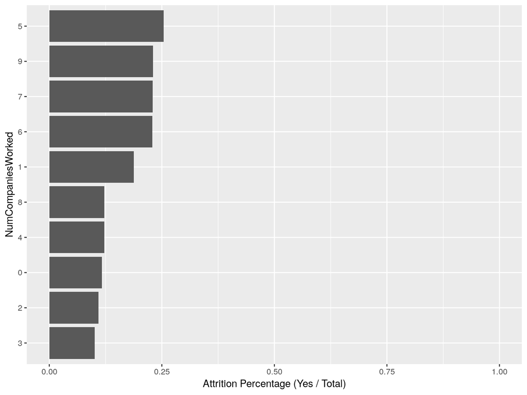

```r
attrition_critical_features %>%
  dplyr::group_by(NumCompaniesWorked, Attrition) %>%
  dplyr::summarise(n = dplyr::n()) %>%
  dplyr::mutate(freq = n / sum(n)) %>%
  dplyr::filter(Attrition == 'Yes') %>%
  ggplot2::ggplot(ggplot2::aes(forcats::fct_reorder(as.factor(NumCompaniesWorked), freq), freq)) +
  ggplot2::geom_bar(stat = 'identity') +
  ggplot2::coord_flip() +
  ggplot2::ylim(0, 1) +
  ggplot2::ylab("Attrition Percentage (Yes / Total)") +
  ggplot2::xlab("NumCompaniesWorked")
```

## Overtime

No surprises here. A large number of employees who stay are not working overtime. Interventions here could include hiring more staff or offering incentives for those times when overtime is necessary.

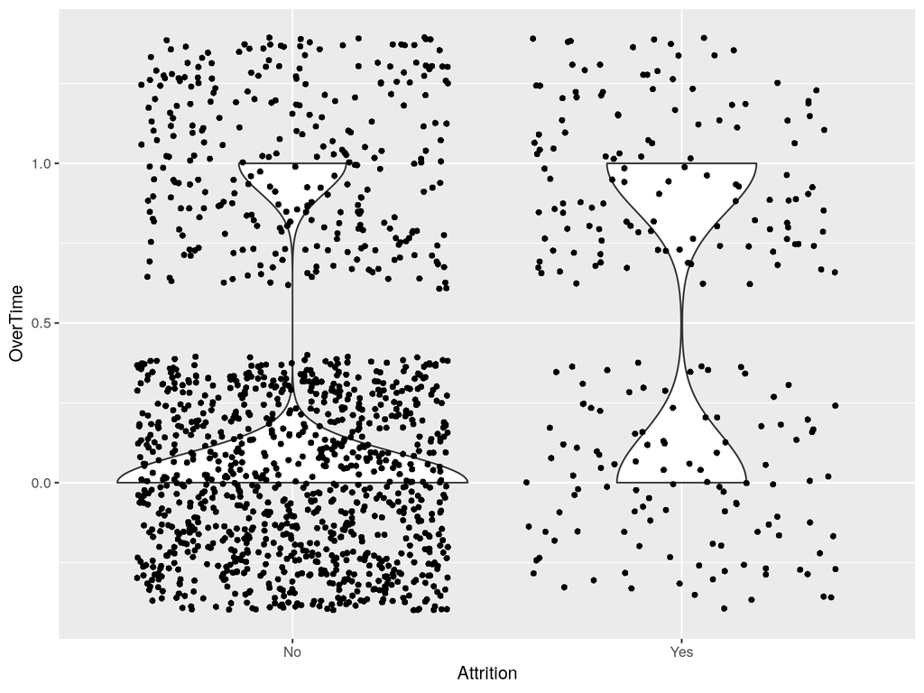

```r
attrition_critical_features %>%
  dplyr::mutate(OverTime = ifelse(OverTime == 'Yes', 1, 0)) %>%
  ggplot2::ggplot(ggplot2::aes(Attrition, OverTime)) +
  ggplot2::geom_violin(trim=TRUE) +
  ggplot2::geom_jitter(shape = 16, position = ggplot2::position_jitter(0.4))
```

## Years Since Last Promotion

Possible interventions here would include promotions or in lieu of that recognition programs.

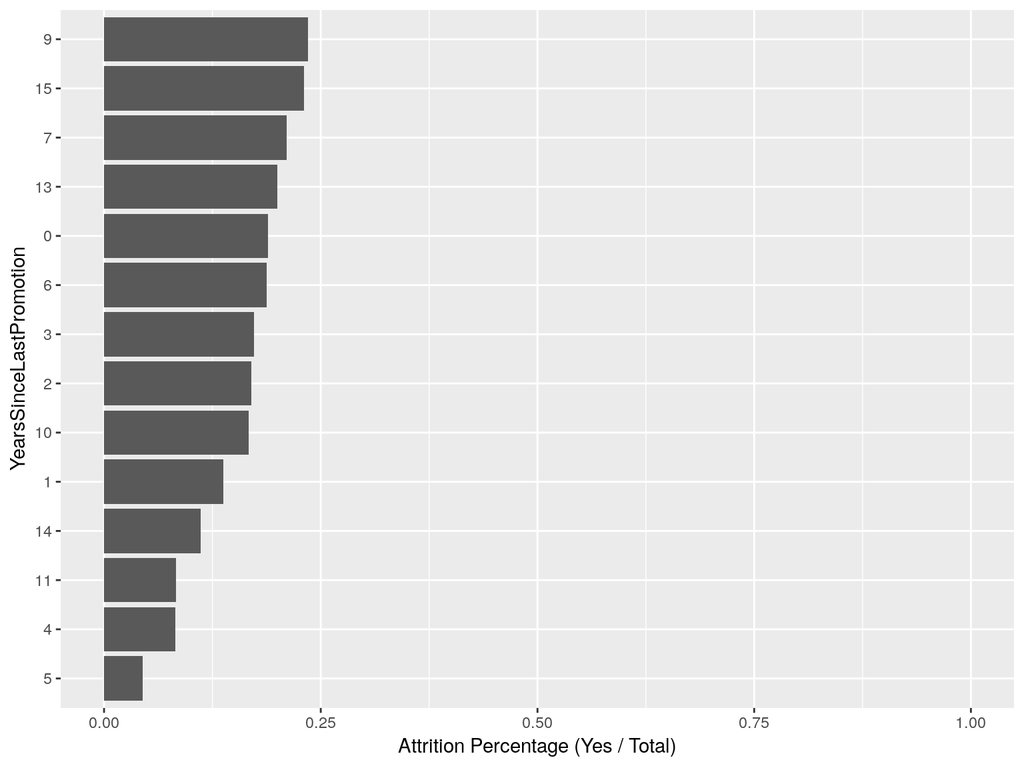

```r
attrition_critical_features %>%
  dplyr::group_by(YearsSinceLastPromotion, Attrition) %>%
  dplyr::summarise(n = dplyr::n()) %>%
  dplyr::mutate(freq = n / sum(n)) %>%
  dplyr::filter(Attrition == 'Yes') %>%
  ggplot2::ggplot(ggplot2::aes(forcats::fct_reorder(as.factor(YearsSinceLastPromotion), freq), freq)) +
  ggplot2::geom_bar(stat = 'identity') +
  ggplot2::coord_flip() +
  ggplot2::ylim(0, 1) +
  ggplot2::ylab("Attrition Percentage (Yes / Total)") +
  ggplot2::xlab("YearsSinceLastPromotion")
```

# Conclusion

Working through this example has been interesting. Not only were we able to explore interesting employee data, but also see how models compare and the pitfalls of not ensuring your work is reproducible.